# Graphics

Alex Filazzola

Oct 2019

[figure not shown]

```r
library(tidyverse)
```

### 4.0 Graphics

Visulization is the final step in data analysis and is definitely an important one. Communicating your data in a way that is easy to understand and shows the trends without misrepresentation can be quite challenging. There are books, courses, and workshops all dedicated to proper data presentation. [**The grammar of graphics**](https://www.amazon.com/Grammar-Graphics-Statistics-Computing/dp/0387245448) is a note worthy example if you are interested in getting deeper into graphic presentation. The short time within this workshop will not be enough to get deeply into it, but I will briefly touch upon how to present some of the trends we observed today.

First, its important to describe that there are two main competing methods for producing plots in R. These are usage of base R graphics vs. ggplot2. There are other methods as well, especially for specific analyses such as network analyses or phylogenetics (see `factoextra` package from ordination section), but these are the leading two methods for more classical figures (e.g. bar plot, scatter plot, boxplot, etc). Both have pros and cons, and each has their day in the light. Me personally, I use ggplot2 for scatter, bar, and box plots, but then use base R for ordinations, cluster analyses, and histograms. I would recommend choosing the method you find easiest because you can generate plots that look identifical using both pathways. Its just a matter of which makes more sense intuitively. Slightly more people say that ggplot2 has a lower learning curve so that is the one I will cover today.

### 4.1 Histograms or density plots

There are resources for understanding the dialect of ggplot, such as this one. One of the key things to understand is that ggplot functions with layers and that call has an almost independent effect on the graph relative to the other elements. Thus, if you are looking for some quick analyses, calling the data and variables in the `ggplot` function is the fastest and most efficient way to produce plots. However, if you are looking for more customization, then the `ggplot` should remain empty and the data called in each argument. Here is an example of what I mean. For this we are going to use the `mtcars` dataset in base R.

```r
head(mtcars)
```

```
##                    mpg cyl disp  hp drat    wt  qsec vs am gear carb
## Mazda RX4         21.0   6  160 110 3.90 2.620 16.46  0  1    4    4
## Mazda RX4 Wag     21.0   6  160 110 3.90 2.875 17.02  0  1    4    4
## Datsun 710        22.8   4  108  93 3.85 2.320 18.61  1  1    4    1
## Hornet 4 Drive    21.4   6  258 110 3.08 3.215 19.44  1  0    3    1
## Hornet Sportabout 18.7   8  360 175 3.15 3.440 17.02  0  0    3    2
## Valiant           18.1   6  225 105 2.76 3.460 20.22  1  0    3    1
```

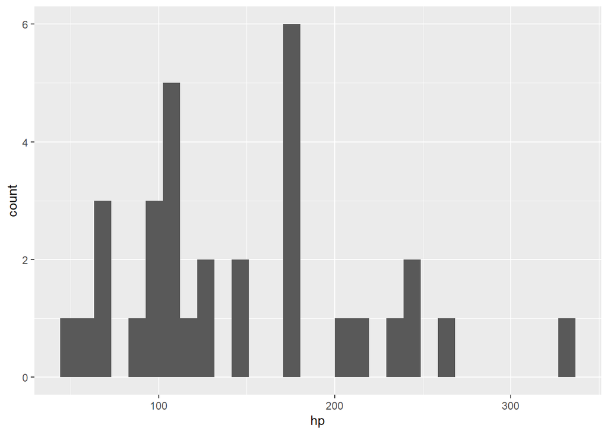

```r
## using data in ggplot call
ggplot(mtcars, aes(x=hp)) + geom_histogram()
```

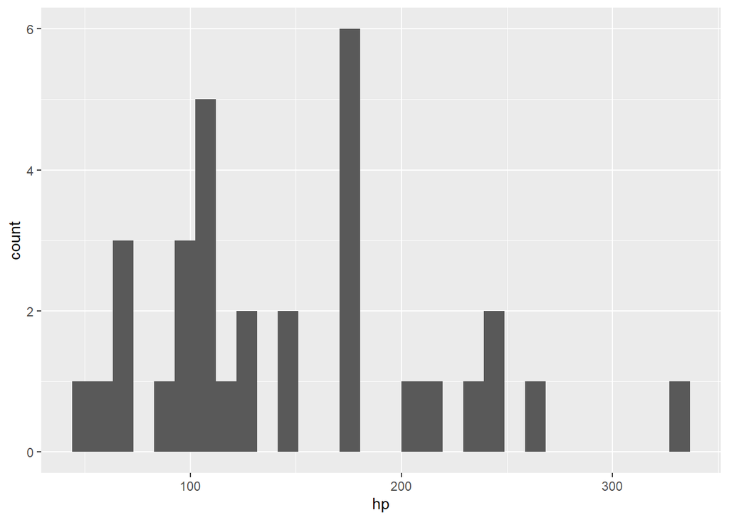

```r
## leaving ggplot empty
ggplot() + geom_histogram(data=mtcars, aes(x=hp))
```

The advantage of the second method is that you can add layers

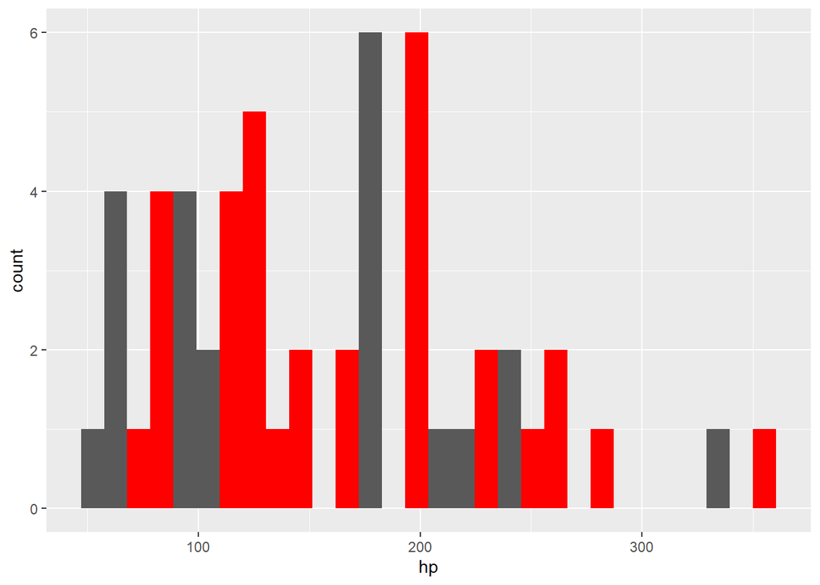

```r
ggplot() + geom_histogram(data=mtcars, aes(x=hp)) + geom_histogram(data=mtcars, aes(x=hp+20), fill="red")
```

In these instances, it may be preferable to use a density plot to have a more smooth response. We can also make the colours transparent to show overlap using the `alpha` arguement.

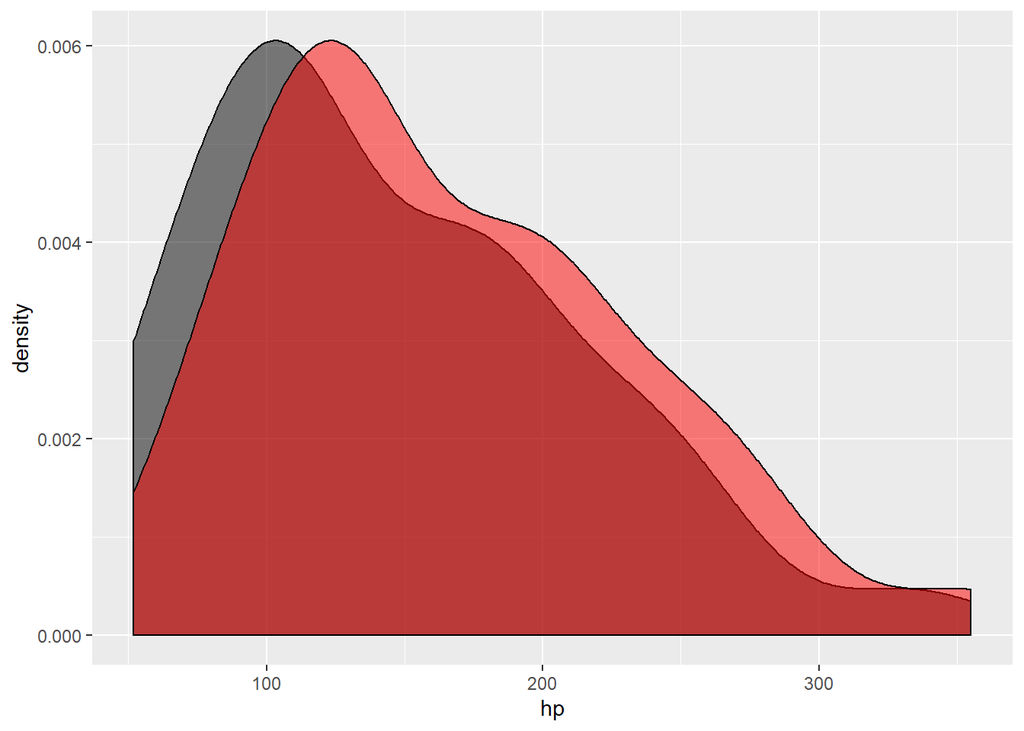

```r
ggplot() + geom_density(data=mtcars, aes(x=hp), fill="black", alpha=0.5) + geom_density(data=mtcars, aes(x=hp+20), fill="red", alpha=0.5)
```

Finally, we clean up the text using the `lab` and `theme` arguments.

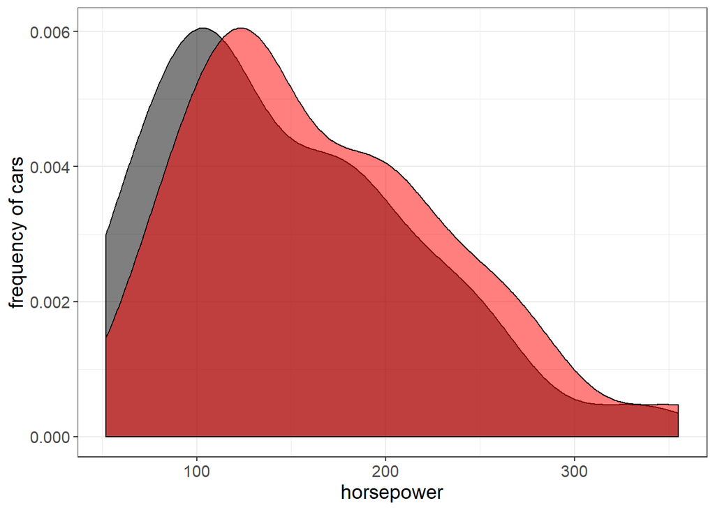

```r
ggplot() + geom_density(data=mtcars, aes(x=hp), fill="black", alpha=0.5) + geom_density(data=mtcars, aes(x=hp+20), fill="red", alpha=0.5) +
  xlab("horsepower") + ylab("frequency of cars") +
  theme_bw() + theme(text = element_text(size=14))
```

### 4.2 Bar plots

Bar plots are among the most challenging of the easy plots to generate. They require first to summarize the data before plotting. Let us compare the differences in horsepower between cars based on the number of cylinders. To do this, we need to calculate the mean and error. We borrow our knowledge of using `group_by` and `summarize`

```r
## write function for error
se <- function(x) { sd(x)/sqrt(length(x))}

## calculate mean and se
carsSummed <- mtcars %>% group_by(cyl) %>% summarize(pwrAvg = mean(hp), pwrSE=se(hp))

carsSummed
```

```
## # A tibble: 3 x 3
##     cyl pwrAvg pwrSE
##   <dbl>  <dbl> <dbl>
## 1     4   82.6  6.31
## 2     6  122.   9.17
## 3     8  209.  13.6
```

Once the stats have been generated you can plot in ggplot

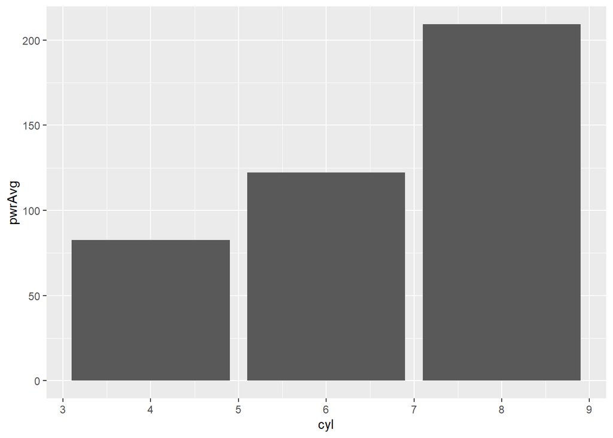

```r
ggplot(carsSummed) + geom_bar(aes(x= cyl, y = pwrAvg), stat="identity")
```

Add error bars

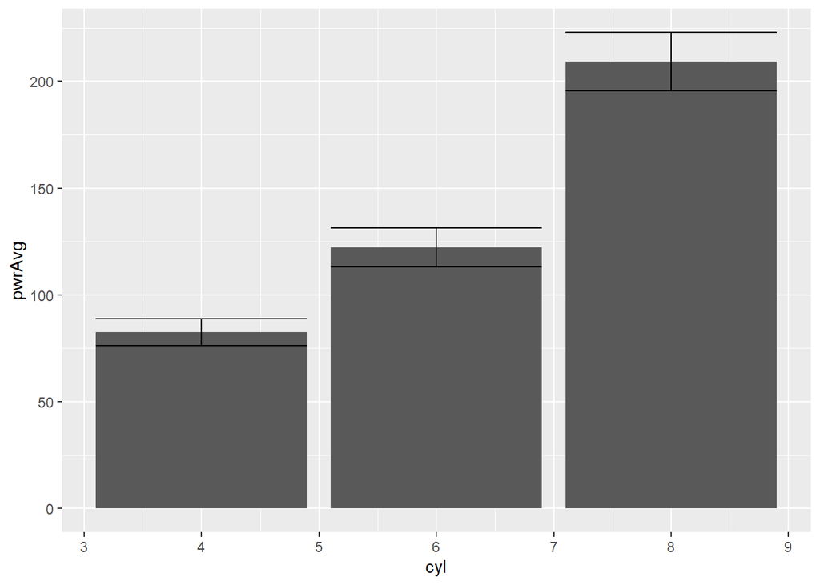

```r
ggplot(carsSummed) + geom_bar(aes(x= cyl, y = pwrAvg), stat="identity") +
  geom_errorbar(aes(x=cyl, ymin=pwrAvg-pwrSE, ymax=pwrAvg+pwrSE))
```

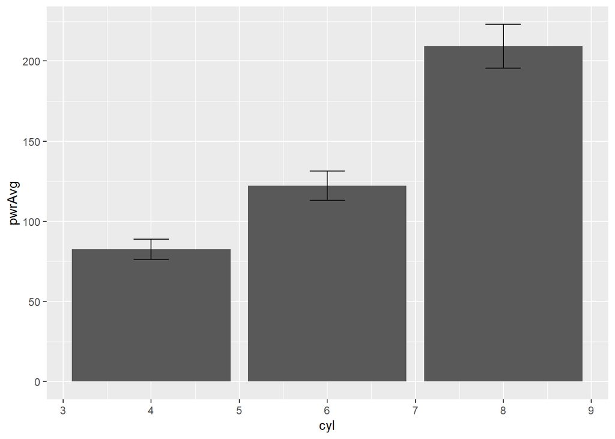

```r
ggplot(carsSummed) + geom_bar(aes(x= cyl, y = pwrAvg), stat="identity") +
  geom_errorbar(aes(x=cyl, ymin=pwrAvg-pwrSE, ymax=pwrAvg+pwrSE), width=0.4)
```